# Exploring Gene Expression

## Introduction

This notebook demonstrates how to identify transcription factors, neuropeptides, and cell surface and adhesion molecules variably expressed in adult and larval RGC clusters. Most of the analysis was run using functionalites within the R package Seurat (Satija et al.,Nature Biotechnology, 2015), an actively maintained set of tools for scRNA-seq analysis (https://satijalab.org/seurat/). `utilFxns.R` and `plottingFxns.R` are scripts containing custom scripts used for analysis and generating figures. These scripts are avaiable in the utils folder at https://github.com/shekharlab/ZebrafishRGC.

## Load gene libraries and objects

The first step is to load necessary packages, libraries, and objects. Additionally, convert all gene names to lowercase for consistency and factor clusters according to their dendrograms.

```r
# Load libraries
library(Seurat)
library(dplyr)
library(reshape2)
library(ggplot2)
source("utils/utilFxns.R") # Some useful functions imported from sc.R
source("utils/plottingFxns.R")

# Load objects
larva <- readRDS("../Objects2020/lar.zFish_Seurat_ClusteredWithPruning_FinalV2_02182020")
larva = LowerCase_genes(larva)
Idents(larva) <- "dendro_order"

adult <- readRDS("../Objects2020/zFish_SeuratClusteredIntegratedPruned_FinalV2_021820.rds")
adult <- LowerCase_genes(adult, integration = TRUE)
adult@active.assay <- "RNA"  #integrated assay does not contain full gene expression
Idents(adult) <- "dendro_order"
```

Next, load in respective gene libraries.

```r
# Transcription factors
tfs = read.csv("../Scripts_Yvonne/ZFIN_Gene_lists/Transcription_Factors.csv", stringsAsFactors = FALSE)$name
num_tfs <- length(tfs)

# Neuropeptides
nps = read.csv("../Scripts_Yvonne/ZFIN_Gene_lists/NP.csv", stringsAsFactors = FALSE)$name
num_nps <- length(nps)

# Axon guidance molecules
axon_guide = read.csv("../Scripts_Yvonne/ZFIN_Gene_lists/Axon_Guidance.csv", stringsAsFactors = FALSE)$name
# Expand for additional cell surface and adhesion molecules
gene_all <- unique(c(rownames(larva@assays$RNA), rownames(adult@assays$RNA)))
CNTN = gene_all[grepl("^cntn",gene_all)] #Contactins
EPH = gene_all[grepl("^eph",gene_all)] #EphRs
EFN = gene_all[grepl("^efn",gene_all)] #Ephrins
ROBO = gene_all[grepl("^robo",gene_all)] #Robos
SLIT = gene_all[grepl("^slit",gene_all)] #Slits
SEMA = gene_all[grepl("^sema",gene_all)] #Semaphorins
PLXN = gene_all[grepl("^plx",gene_all)] #Plexins
NRP = gene_all[grepl("^nrp",gene_all)] #Neuropilins
CDH = gene_all[grepl("^cdh",gene_all)] #Cadherins
PCDH = gene_all[grepl("^pcdh",gene_all)] #Protocadherins
NCAM = gene_all[grepl("^ncam",gene_all)] #Neuronal CAMs
CADM = gene_all[grepl("^cadm",gene_all)] #Cell adhesion molecule
LRRTM = gene_all[grepl("^lrrtm",gene_all)] #Leucine-rich repeat transmembrane proteins

RecMol <- unique(c(axon_guide, CNTN, EPH, EFN, ROBO, SLIT, SEMA, PLXN, NRP, CDH, PCDH, NCAM, CADM, LRRTM))
num_RMs <- length(RecMol)
```

## Investigating gene expression in larval clusters

Identify transcription factors expressed in larval clusters

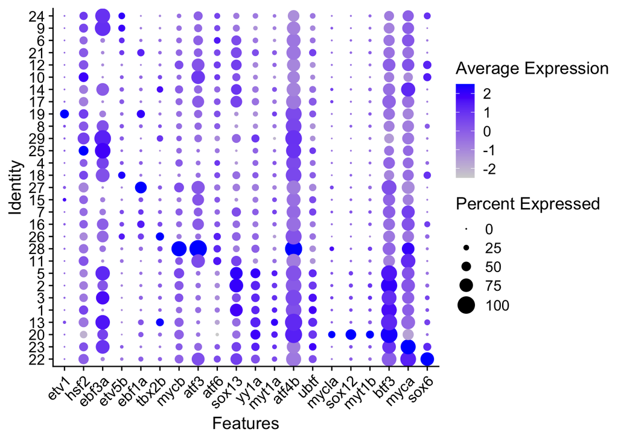

```r
# Subset for genes identified in the larva dataset
tfs_larva <- tfs[tfs %in% rownames(larva)]

# Generate a matrix with each entry corresponding to percent expression of a gene (row) in a cluster (column)
num_idents <- length(levels(Idents(larva)))
per_express <- lapply(1:num_idents, function(x) tfPercentExpression(larva, clusID = x, tf=tfs_larva, threshold = 1))
per_express_mat <- matrix(unlist(per_express), ncol=num_idents, dimnames = list(tfs_larva, 1:num_idents))

# Define different types of markers based on the percentage of cells expressing a given gene
percentage_expressing <- .3
num_expressing_clusters <- rowSums(per_express_mat > percentage_expressing)
larva_TFs <- rownames(per_express_mat)[which(num_expressing_clusters > 0)]

# Plot a subset of TFs
plot_TFs <- DiagonalizeGenes(larva_TFs[1:20], larva)
DotPlot(larva, features = plot_TFs) + RotatedAxis()
```

Identify neuropeptides expressed in larval clusters.

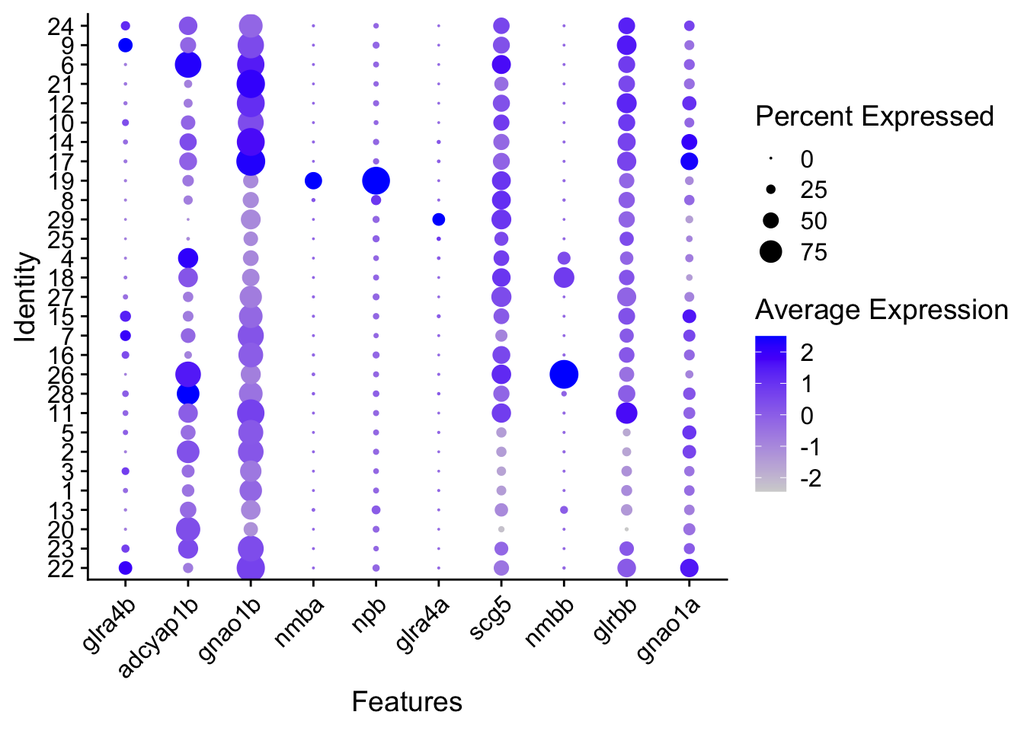

```r
# Subset for genes identified in the larva dataset
nps_larva <- nps[nps %in% rownames(larva)]

# Generate a matrix with each entry corresponding to percent expression of a gene (row) in a cluster (column)
num_idents <- length(levels(Idents(larva)))
per_express <- lapply(1:num_idents, function(x) tfPercentExpression(larva, clusID = x, tf=nps_larva, threshold = 0))
per_express_mat <- matrix(unlist(per_express), ncol=num_idents, dimnames = list(nps_larva, 1:num_idents))

# Define different types of markers based on the percentage of cells expressing a given gene
percentage_expressing <- .3
num_expressing_clusters <- rowSums(per_express_mat > percentage_expressing)
larva_NPs <- rownames(per_express_mat)[which(num_expressing_clusters > 0)]

# Plot neuropeptides as Dot Plots
DotPlot(larva, features = DiagonalizeGenes(larva_NPs, larva)) + RotatedAxis()
```

Identify cell surface and adhesion molecules expressed in larval clusters.

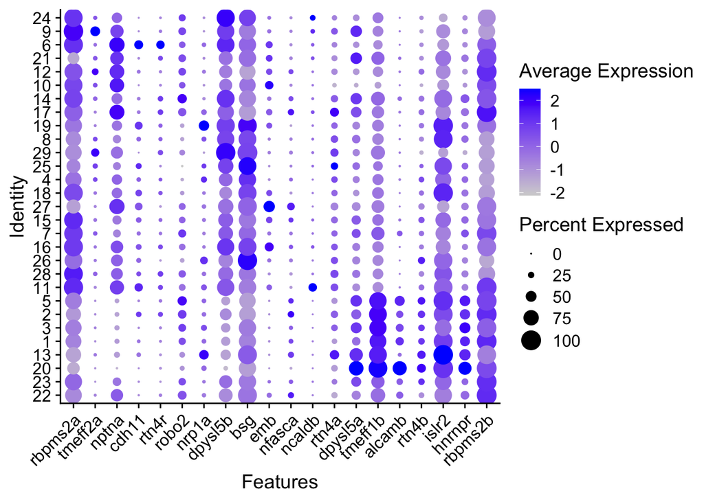

```r
# Subset for genes identified in the larva dataset
RecMol_larva <- RecMol[RecMol %in% rownames(larva)]


# Generate a matrix with each entry corresponding to percent expression of a gene (row) in a cluster (column)
num_idents <- length(levels(Idents(larva)))
per_express <- lapply(1:num_idents, function(x) tfPercentExpression(larva, clusID = x, tf=RecMol_larva, threshold = 0))
per_express_mat <- matrix(unlist(per_express), ncol=num_idents, dimnames = list(RecMol_larva, 1:num_idents))

# Define different types of markers based on the percentage of cells expressing a given gene
percentage_expressing <- .3
num_expressing_clusters <- rowSums(per_express_mat > percentage_expressing)
larva_RMs <- rownames(per_express_mat)[which(num_expressing_clusters > 0)]

# Plot a subset of molecules
DotPlot(larva, features = DiagonalizeGenes(larva_RMs[1:20], larva)) + RotatedAxis()
```

## Investigating gene expression in adult clusters

Identify transcription factors expressed in adult clusters.

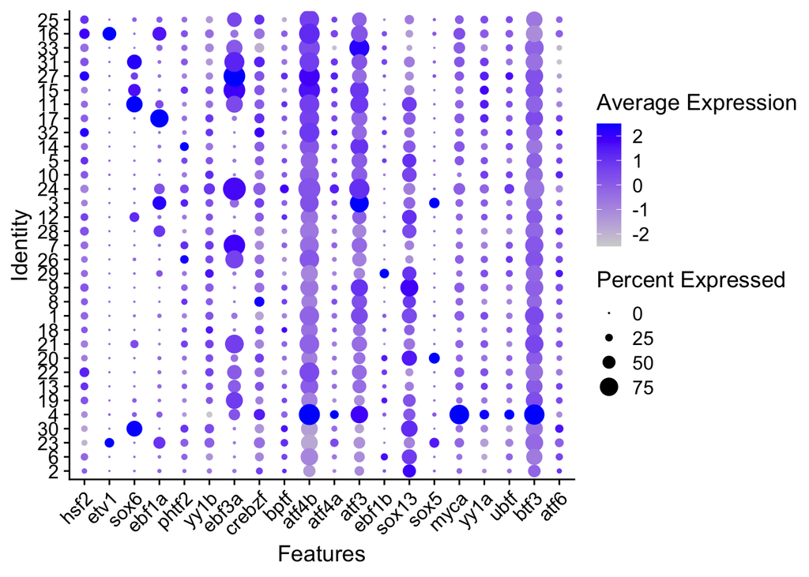

```r
# Subset for genes identified in the adult dataset
tfs_adult <- tfs[tfs %in% rownames(adult)]

# Generate a matrix with each entry corresponding to percent expression of a gene (row) in a cluster (column)
num_idents <- length(levels(Idents(adult)))
per_express <- lapply(1:num_idents, function(x) tfPercentExpression(adult, clusID = x, tf=tfs_adult, threshold = 0))
per_express_mat <- matrix(unlist(per_express), ncol=num_idents, dimnames = list(tfs_adult, 1:num_idents))

# Define different types of markers based on the percentage of cells expressing a given gene
percentage_expressing <- .3
num_expressing_clusters <- rowSums(per_express_mat > percentage_expressing)
adult_TFs <- rownames(per_express_mat)[which(num_expressing_clusters > 0)]

# Plot a subset of transcription factors
DotPlot(adult, features = DiagonalizeGenes(adult_TFs[1:20], adult)) + RotatedAxis()
```

Identify neuropeptides expressed in adult clusters.

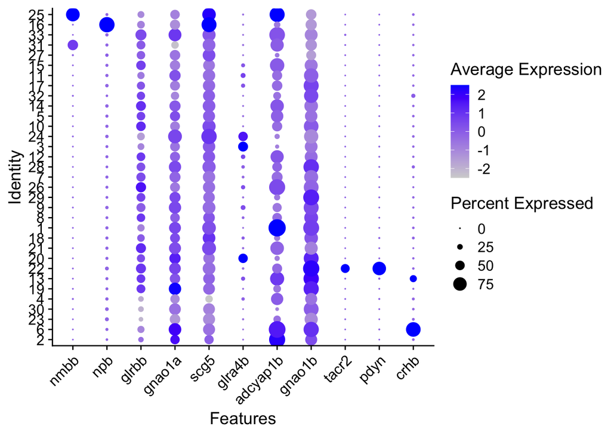

```r
# Subset for genes identified in the adult dataset
nps_adult <- nps[nps %in% rownames(adult)]

# Generate a matrix with each entry corresponding to percent expression of a gene (row) in a cluster (column)
num_idents <- length(levels(Idents(adult)))
per_express <- lapply(1:num_idents, function(x) tfPercentExpression(adult, clusID = x, tf=nps_adult, threshold = 1))
per_express_mat <- matrix(unlist(per_express), ncol=num_idents, dimnames = list(nps_adult, 1:num_idents))

# Define different types of markers based on the percentage of cells expressing a given gene
percentage_expressing <- .3
num_expressing_clusters <- rowSums(per_express_mat > percentage_expressing)
adult_NPs <- rownames(per_express_mat)[which(num_expressing_clusters > 0)]

# Plot neuropeptides
DotPlot(adult, features = DiagonalizeGenes(adult_NPs, adult)) + RotatedAxis()
```

Identify cell surface and adhesion molecules expressed in adult clusters.

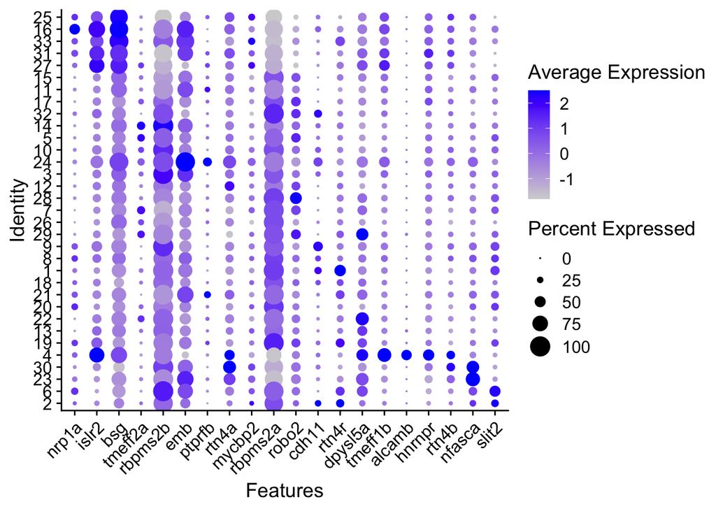

```r
# Subset for genes identified in the adult dataset
RecMol_adult <- RecMol[RecMol %in% rownames(adult)]

# Generate a matrix with each entry corresponding to percent expression of a gene (row) in a cluster (column)
num_idents <- length(levels(Idents(adult)))
per_express <- lapply(1:num_idents, function(x) tfPercentExpression(adult, clusID = x, tf=RecMol_adult, threshold = 0))
per_express_mat <- matrix(unlist(per_express), ncol=num_idents, dimnames = list(RecMol_adult, 1:num_idents))

# Define different types of markers based on the percentage of cells expressing a given gene
percentage_expressing <- .3
num_expressing_clusters <- rowSums(per_express_mat > percentage_expressing)
adult_RMs <- rownames(per_express_mat)[which(num_expressing_clusters > 0)]

# Plot a subset of genes
DotPlot(adult, features = DiagonalizeGenes(adult_RMs[1:20], adult)) + RotatedAxis()
```

## Hyper geometric test

Calculate the probability that shared gene expression between larval and adult is random using the hypergeometric test.

```r
TF_p_val <- phyper(q = sum(as.numeric(adult_TFs %in% larva_TFs)), m = length(larva_TFs), n = num_tfs - length(larva_TFs), k = length(adult_TFs), lower.tail = FALSE)
print(paste0("Transcription factor p-val: ", TF_p_val))
```

```
## [1] "Transcription factor p-val: 1.65481757421276e-132"
```

```r
NP_p_val <- phyper(q = sum(as.numeric(adult_NPs %in% larva_NPs)), m = length(larva_NPs), n = num_nps - length(larva_NPs), k = length(adult_NPs), lower.tail = FALSE)
print(paste0("Neuropeptide p-val: ", NP_p_val))
```

```
## [1] "Neuropeptide p-val: 4.05238110889351e-12"
```

```r
RM_p_val <- phyper(q = sum(as.numeric(adult_RMs %in% larva_RMs)), m = length(larva_RMs), n = num_RMs - length(larva_RMs), k = length(adult_RMs), lower.tail = FALSE)
print(paste0("Recognition molecule p-val: ", RM_p_val))
```

```
## [1] "Recognition molecule p-val: 1.28383464357266e-50"
```